# Package Week1 이재현

# Chpater1. 전처리

### 문제 0 기본 세팅. 패키지를 plyr, tidyverse, data.table 순으로 부른 후, setwd로 ‘data.csv’가 있는 폴더로 경로를설정하고, fread로 ‘data.csv’를 불러오세요.

```r
library(plyr)
library(tidyverse)
library(data.table)
setwd("C:/Users/jhlee/Desktop/1주차패키지")
mydata <- fread("data.csv")
```

### 문제 1 데이터 확인하기. str으로 데이터의 구성을 살펴보고, 각 열마다 NA 개수와 unique 값 및 개수를 확인해 보세요. (colSums, unique, length 이용 시 편리)

```r
str(mydata)
```

```
## Classes 'data.table' and 'data.frame':   5165 obs. of  8 variables:
##  $ patient_id    :integer64 1000000001 1000000002 1000000003 1000000004 1000000005 1000000006 1000000007 1000000008 ...
##  $ sex           : chr  "male" "male" "male" "male" ...
##  $ age           : chr  "50s" "30s" "50s" "20s" ...
##  $ country       : chr  "Korea" "Korea" "Korea" "Korea" ...
##  $ province      : chr  "서울" "서울" "서울" "서울" ...
##  $ city          : chr  "강서구" "중랑구" "종로구" "마포구" ...
##  $ confirmed_date: IDate, format: "2020-01-23" "2020-01-30" ...
##  $ state         : chr  "released" "released" "released" "released" ...
##  - attr(*, ".internal.selfref")=<externalptr>
```

```r
colSums(is.na(mydata))
```

```
##     patient_id            sex            age        country       province
##              0              0              0              0              0
##           city confirmed_date          state
##              0              3              0
```

```r
mydata %>%
  summarise_all(funs(n_distinct))
```

```
##   patient_id sex age country province city confirmed_date state
## 1       5164   3  12      16       17  163            149     3
```

```r
head(unique(mydata$patient_id)) #너무 많아서 일부만 출력
```

```
## integer64
## [1] 1000000001 1000000002 1000000003 1000000004 1000000005 1000000006
```

```r
unique(mydata$sex)
```

```
## [1] "male"   "female" ""
```

```r
unique(mydata$age)
```

```
##  [1] "50s"  "30s"  "20s"  "60s"  "80s"  "70s"  "40s"  "10s"  "90s"  "0s"
## [11] ""     "100s"
```

```r
unique(mydata$country)
```

```
##  [1] "Korea"          "China"          "United States"  "France"
##  [5] "Thailand"       "Canada"         "India"          "Switzerland"
##  [9] "Germany"        "Indonesia"      "Vietnam"        "Foreign"
## [13] "Mongolia"       "United Kingdom" "Spain"          "Bangladesh"
```

```r
unique(mydata$province)
```

```
##  [1] "서울"     "부산"     "대구"     "광주"     "인천"     "대전"
##  [7] "경기도"   "세종"     "울산"     "강원도"   "충청북도" "충청남도"
## [13] "전라북도" "전라남도" "경상북도" "경상남도" "제주도"
```

```r
head(unique(mydata$city))
```

```
## [1] "강서구" "중랑구" "종로구" "마포구" "성북구" "기타"
```

```r
head(unique(mydata$confirmed_date))
```

```
## [1] "2020-01-23" "2020-01-30" "2020-01-31" "2020-02-02" "2020-02-05"
## [6] "2020-02-06"
```

```r
unique(mydata$state)
```

```
## [1] "released" "deceased" "isolated"
```

### 문제 2-1. NA가 있는 행을 삭제하세요.

```r
mydata <- na.omit(mydata)
```

### 문제 2-2 빈 문자열(“”)이 있는 행을 삭제하고, 각 열마다 NA 개수와 unique 값 및 개수를 다시 확인해 보세요.(which, 논리연산자 이용 시 편리)

```r
mydata <- mydata %>%
  filter(sex != "" & age != "" & country != "" & province != "" & city != "" & state != "")

colSums(is.na(mydata))
```

```
##     patient_id            sex            age        country       province
##              0              0              0              0              0
##           city confirmed_date          state
##              0              0              0
```

```r
mydata %>%
  summarise_all(funs(n_distinct))
```

```
##   patient_id sex age country province city confirmed_date state
## 1       3689   2  11      15       16  158            145     3
```

```r
head(unique(mydata$patient_id))
```

```
## integer64
## [1] 1000000001 1000000002 1000000003 1000000004 1000000005 1000000006
```

```r
unique(mydata$sex)
```

```
## [1] "male"   "female"
```

```r
unique(mydata$age)
```

```
##  [1] "50s"  "30s"  "20s"  "60s"  "80s"  "70s"  "40s"  "10s"  "90s"  "0s"
## [11] "100s"
```

```r
unique(mydata$country)
```

```
##  [1] "Korea"          "China"          "United States"  "France"
##  [5] "Thailand"       "Canada"         "Switzerland"    "Germany"
##  [9] "Indonesia"      "Vietnam"        "Foreign"        "Mongolia"
## [13] "United Kingdom" "Spain"          "Bangladesh"
```

```r
unique(mydata$province)
```

```
##  [1] "서울"     "부산"     "대구"     "인천"     "대전"     "경기도"
##  [7] "세종"     "울산"     "강원도"   "충청북도" "충청남도" "전라북도"
## [13] "전라남도" "경상북도" "경상남도" "제주도"
```

```r
head(unique(mydata$city))
```

```
## [1] "강서구" "중랑구" "종로구" "마포구" "성북구" "기타"
```

```r
head(unique(mydata$confirmed_date))
```

```
## [1] "2020-01-23" "2020-01-30" "2020-01-31" "2020-02-02" "2020-02-05"
## [6] "2020-02-06"
```

```r
unique(mydata$state)
```

```
## [1] "released" "deceased" "isolated"
```

### 문제3. country가 ‘Korea’인 행만 남긴 다음, country 열을 제거하세요.

```r
mydata <- mydata %>%
  filter(country == "Korea") %>%
  select(-country)
```

### 문제 4. province 변수 내 ‘서울, 부산, 대구, 인천, 대전, 세종, 울산, 제주도’ 값을 다음과 같이 바꾸세요.

```r
mydata$province <- mapvalues(mydata$province, from = c("서울","부산","대구","인천","대전","세종","울산","제주도"),c("서울특별시","부산광역시","대구광역시","인천광역시","대전광역시","세종특별자치시","울산광역시","제주특별자치도"))
```

### 문제 5. confirmed_date를 날짜 자료형(Date)으로 바꾸세요.

```r
mydata$confirmed_date <- as.Date(mydata$confirmed_date)
```

### 문제 6. 확진날짜(confirmed_date) 별 확진자 수에 대한 파생변수를 만드세요. (파생변수 이름 : confirmed_number)

```r
mydata <- mydata %>%
  dplyr::group_by(confirmed_date) %>%
  dplyr::mutate(confirmed_number = n())

mydata %>%
  select(patient_id, confirmed_date,confirmed_number) %>%
  head(50)
```

```
## # A tibble: 50 x 3
## # Groups:   confirmed_date [16]
##    patient_id confirmed_date confirmed_number
##       <int64> <date>                    <int>
##  1 1000000001 2020-01-23                    1
##  2 1000000002 2020-01-30                    4
##  3 1000000003 2020-01-30                    4
##  4 1000000004 2020-01-30                    4
##  5 1000000005 2020-01-31                    3
##  6 1000000006 2020-01-31                    3
##  7 1000000007 2020-01-31                    3
##  8 1000000008 2020-02-02                    2
##  9 1000000009 2020-02-05                    4
## 10 1000000010 2020-02-05                    4
## # ... with 40 more rows
```

### 문제 7. 확진날짜(confirmed_date)의 주말 여부에 대한 파생변수를 만드세요. (파생변수 이름 : wday)

```r
mydata <- mydata %>%
  mutate(wday = ifelse(weekdays(confirmed_date) == "토요일" | weekdays(confirmed_date) == "일요일","주말","주중"))
```

### 문제 8. 나이대 별 일별 확진자 수에 대한 summary를 확인해 보세요. (예 : 10대의 날짜별 확진자 수의 분포)

```r
num_data3 <- mydata %>%
  group_by(age,confirmed_date) %>%
  dplyr::summarise(confirmed_num = n())
tapply(num_data3$confirmed_num,num_data3$age ,summary)
```

```
## $`0s`
##    Min. 1st Qu.  Median    Mean 3rd Qu.    Max.
##   1.000   1.000   1.000   1.488   2.000   3.000
##
## $`100s`
##    Min. 1st Qu.  Median    Mean 3rd Qu.    Max.
##       1       1       1       1       1       1
##
## $`10s`
##    Min. 1st Qu.  Median    Mean 3rd Qu.    Max.
##   1.000   1.000   2.000   2.276   3.000   8.000
##
## $`20s`
##    Min. 1st Qu.  Median    Mean 3rd Qu.    Max.
##   1.000   1.000   3.500   7.526  11.000  43.000
##
## $`30s`
##    Min. 1st Qu.  Median    Mean 3rd Qu.    Max.
##   1.000   2.000   3.000   5.051   8.000  17.000
##
## $`40s`
##    Min. 1st Qu.  Median    Mean 3rd Qu.    Max.
##   1.000   1.000   2.000   4.931   6.000  33.000
##
## $`50s`
##    Min. 1st Qu.  Median    Mean 3rd Qu.    Max.
##   1.000   1.000   3.000   6.112   9.000  31.000
##
## $`60s`
##    Min. 1st Qu.  Median    Mean 3rd Qu.    Max.
##   1.000   1.000   3.000   4.722   7.000  22.000
##
## $`70s`
##    Min. 1st Qu.  Median    Mean 3rd Qu.    Max.
##   1.000   1.000   2.000   2.908   3.250  13.000
##
## $`80s`
##    Min. 1st Qu.  Median    Mean 3rd Qu.    Max.
##   1.000   1.000   2.000   3.019   3.750  24.000
##
## $`90s`
##    Min. 1st Qu.  Median    Mean 3rd Qu.    Max.
##   1.000   1.000   1.000   2.286   2.000  16.000
```

# Chpater2. 시각화

### 문제 1 Line Plot. confirmed_date와 confirmed_number 변수를 이용하여 확진자수 추이 그래프를 그리고, 최대 확진자에 대한 정보도 표시하세요. (적절한 함수를 이용하여 #대신 정확한 날짜 및 수를 쓸 것 , 색:navy, lightblue, 제목:bold체)

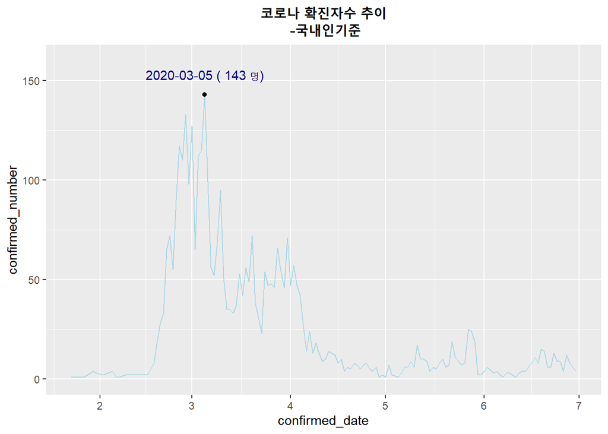

```r
mydata <- mydata %>%
  dplyr::group_by(confirmed_date) %>%
  dplyr::mutate(confirmed_number = n())

max_num <- max(mydata$confirmed_number)


summ_date <- mydata %>%
  group_by(confirmed_date) %>%
  dplyr::summarise(confirmed_number = n())

summ_date <- as.data.frame(summ_date)
summ_date <- summ_date %>%
  filter(confirmed_number == max_num)
summ_example <- column_to_rownames(summ_date, var = "confirmed_number")

max_date <- summ_example$confirmed_date
text <- paste(as.character(max_date),"(",as.character(max_num),"명)", collapse = "")
ggplot(data = mydata,aes(x = confirmed_date,y = confirmed_number)) +
  ggtitle("코로나 확진자수 추이\n -국내인기준")+
  theme(plot.title = element_text(family = "serif",face = "bold", hjust = 0.5)) +
  geom_line(color = "lightblue") +
  ylim(0,160) +
  geom_point(data = summ_date, aes(x = confirmed_date, y = confirmed_number)) +
  annotate("text", x = max_date, y = max_num+10 , label = text,color = "navy")
```

### 1-2. 문제 1-2 Line Plot. province 별 확진자 수 추이 그래프를 그리세요

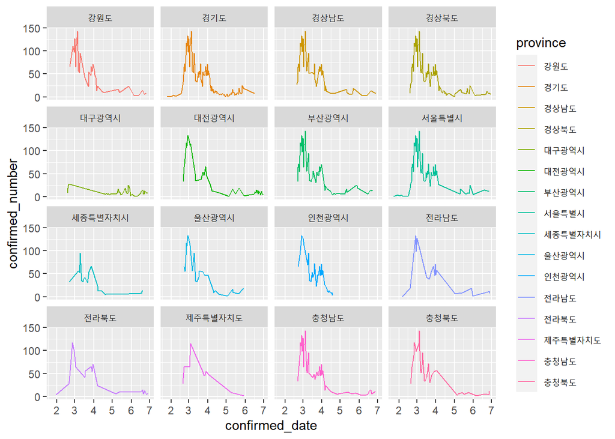

```r
prov_data <- mydata %>%
  select(province,confirmed_date) %>%
  arrange(province)

ggplot(data = mydata, aes(x=confirmed_date, y = confirmed_number,group = province, color = province)) +
  geom_line() +
  facet_wrap(~province)
```

### 문제 2 Bar Plot. 지역별 확진자 수를 state(확진자 상황) 그룹 별로 나누어 그래프를 그리세요.

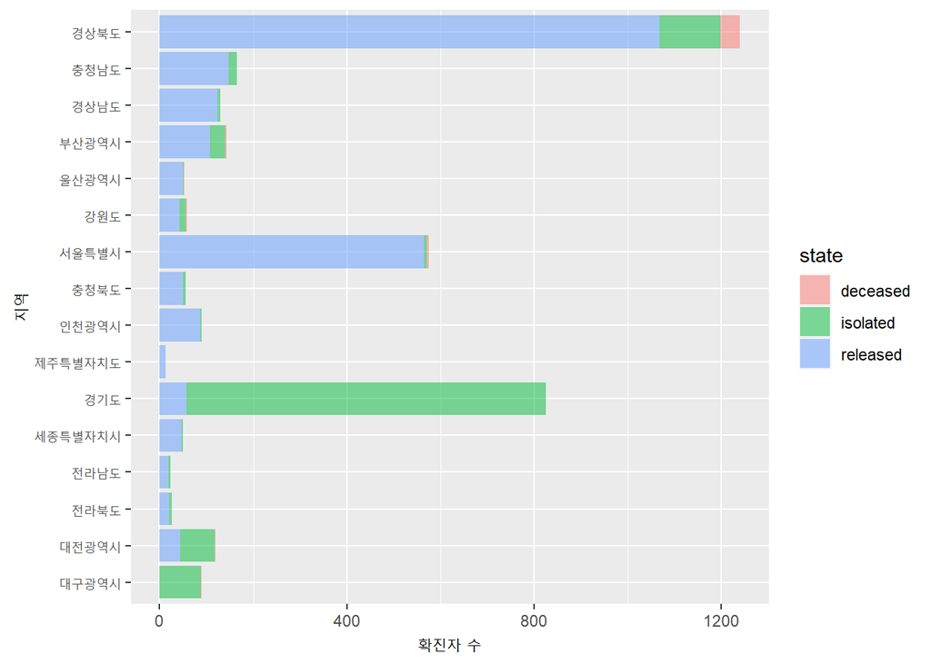

```r
bar_data <- mydata %>%
  mutate(n = n()) %>%
  arrange(desc(n))


ggplot(data = bar_data, aes(x = reorder(province,n), fill = state)) +
  geom_bar(alpha = 0.5) +
  coord_flip()+
  labs(x = "지역",
       y = "확진자 수")
```

### 문제3 Box Plot. 나이대별 일별 확진자 수 box plot을 그리세요

```r
box_data <- mydata %>%
  group_by(age,confirmed_date) %>%
  dplyr::summarise(confirmed_num = n())
```

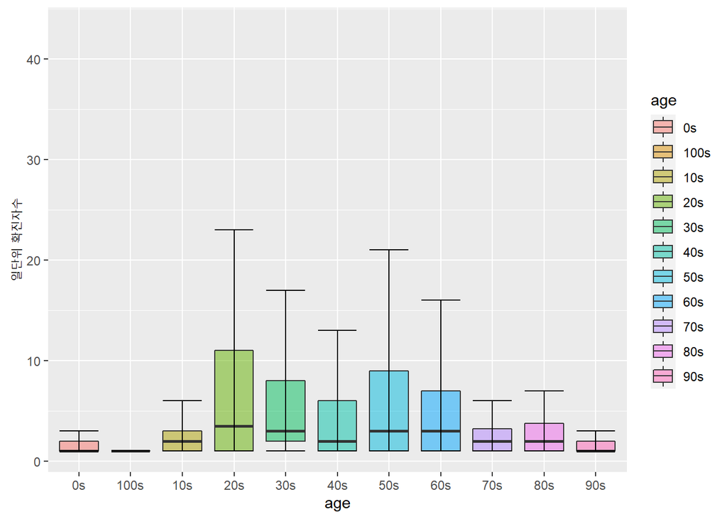

```r
ggplot(data = box_data, aes(x = age, y = confirmed_num,fill = age)) +
  geom_boxplot(outlier.shape = NA,alpha = 0.5) +
  stat_boxplot(geom = 'errorbar') +
  labs(x = "age", y = "일단위 확진자수")
```

### 문제 3-2 . 나이대별 일별 확진자 수에 대한 일원분산분석(one-way ANOVA)을 실시하여 해석해 보세요

```r
summary(aov(confirmed_num~age,data = box_data))
```

```
##              Df Sum Sq Mean Sq F value   Pr(>F)
## age          10   2575  257.48   8.823 8.19e-14 ***
## Residuals   780  22764   29.18
## ---
## Signif. codes:  0 '***' 0.001 '**' 0.01 '*' 0.05 '.' 0.1 ' ' 1
```

=> 검정통계량이 F-value보다 크므로, 이는 기각역에 존재하고, 귀무가설을 기각한다. 즉, 나이대별 일별 확진자 수는 집단간 평균의 차이가 존재한다.

# Chpater3. 모델링_회귀분석

### 문제 1. 아래처럼 상관계수 플랏을 만들고 간단히 해석해 보세요.

```r
library(MASS)
```

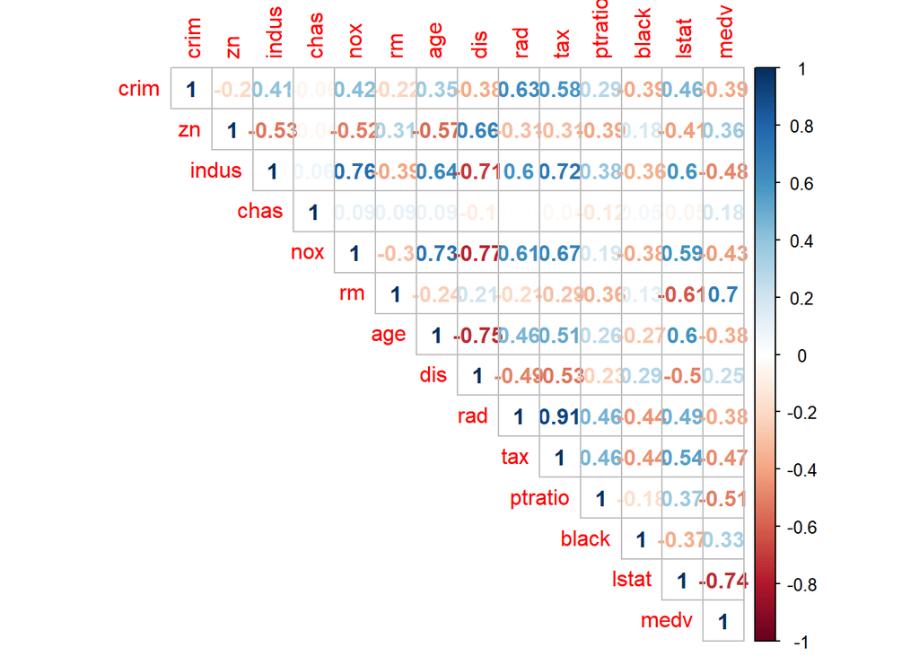

```r
library(corrplot)
library(caret)
library(MLmetrics)
bos <- as.data.frame(MASS::Boston)

bos_cor <- cor(bos)

corrplot(bos_cor,
         method = "number",
         type = "upper",
         )
```

=> nox와 indus, nox와 age, rad와 tax는 양의 상관관계에 있는 편이고, dis와 indus, dis와 nox, dis와 age, lstat과 medv등은 음의 상관관계에 있는 편이다.

### 문제 2. 아래와 같이 종속변수로 사용할 medv와 이외 변수 간의 관계 파악을 위한 scatterplot 및 회귀 추세선을 그려보세요. (gather 이용 시 편리, 색 : lightblue)

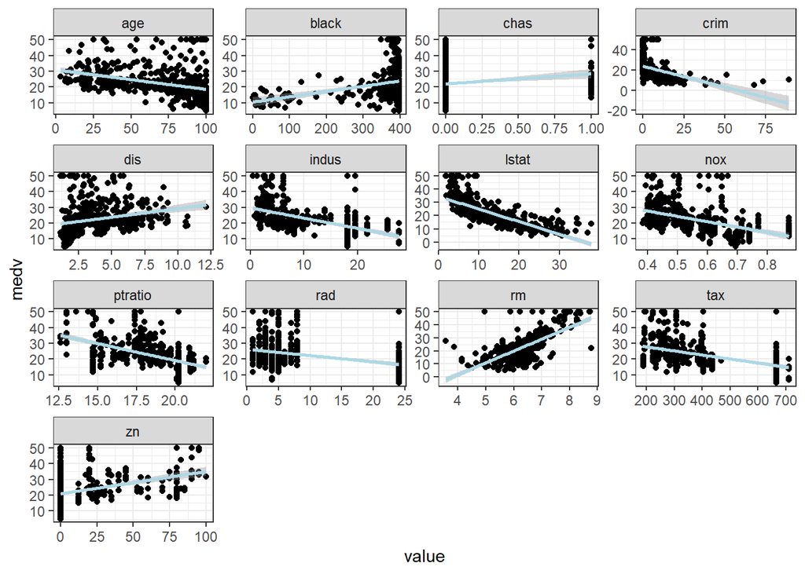

```r
bos %>%
  gather(-medv, key = "var", value = "value") %>%
  ggplot(aes(x = value, y = medv)) +
  geom_point() +
  facet_wrap(~var, scales = "free")+
  theme_bw()+
  stat_smooth(color = "lightblue",method = "lm")
```

### 문제 3. 데이터를 train/test 데이터를 7:3으로 나누세요 (1234로 시드 고정 필수)

```r
set.seed(1234)

test_index <- createDataPartition(
  bos$medv, p = 0.3, list = FALSE)

test_data <- bos[test_index,]
train_data <- bos[-test_index,]
```

### 문제 3-2. train 데이터로 medv를 종속변수로 하고 나머지를 모두 독립 변수로 하는 회귀 모형을 만든 후 간단히 결과를 해석한 후, test에 대한 RMSE를 구하세요.

```r
train_fit <- lm(train_data$medv~., data = train_data)


summary(train_fit)
```

```
##
## Call:
## lm(formula = train_data$medv ~ ., data = train_data)
##
## Residuals:
##      Min       1Q   Median       3Q      Max
## -18.0384  -2.9740  -0.6509   1.9955  25.8605
##
## Coefficients:
##               Estimate Std. Error t value Pr(>|t|)
## (Intercept)  31.338469   6.443165   4.864 1.77e-06 ***
## crim         -0.062724   0.052645  -1.191 0.234314
## zn            0.033353   0.017059   1.955 0.051385 .
## indus        -0.002893   0.078701  -0.037 0.970694
## chas          4.117611   1.041972   3.952 9.45e-05 ***
## nox         -17.877732   4.548014  -3.931 0.000103 ***
## rm            4.658799   0.524966   8.874  < 2e-16 ***
## age          -0.009814   0.015968  -0.615 0.539248
## dis          -1.385488   0.238406  -5.811 1.43e-08 ***
## rad           0.249784   0.085407   2.925 0.003681 **
## tax          -0.010480   0.004763  -2.200 0.028452 *
## ptratio      -0.968775   0.160672  -6.030 4.31e-09 ***
## black         0.008569   0.003464   2.474 0.013854 *
## lstat        -0.443657   0.063281  -7.011 1.29e-11 ***
## ---
## Signif. codes:  0 '***' 0.001 '**' 0.01 '*' 0.05 '.' 0.1 ' ' 1
##
## Residual standard error: 4.886 on 338 degrees of freedom
## Multiple R-squared:  0.7459, Adjusted R-squared:  0.7362
## F-statistic: 76.34 on 13 and 338 DF,  p-value: < 2.2e-16
```

=> F통계량의 p-value 값이 유의 수준보다 작으므로 통계적으로 유의하다

```r
test_fit <- lm(test_data$medv~., data = test_data)
prediction <- predict(test_fit, test_data)

RMSE(test_data$medv,prediction)
```

```
## [1] 3.989781
```

### 문제 3-3. 모델의 RMSE를 낮출 수 있는 방법에 대해 간략히 설명해 주세요.

1. 이상치(outlier)들을 찾아내어 대표값(평균 혹은 중간값)으로 대체한다.
2. 더 적합한 회귀모형을 찾아낸다.

```r
train_plot_data <- as.data.frame(train_fit$coefficients)
train_plot_data
```

```
##             train_fit$coefficients
## (Intercept)           31.338468702
## crim                  -0.062723667
## zn                     0.033353221
## indus                 -0.002893420
## chas                   4.117610945
## nox                  -17.877732453
## rm                     4.658798780
## age                   -0.009813774
## dis                   -1.385487978
## rad                    0.249784049
## tax                   -0.010480226
## ptratio               -0.968774867
## black                  0.008569326
## lstat                 -0.443656781
```

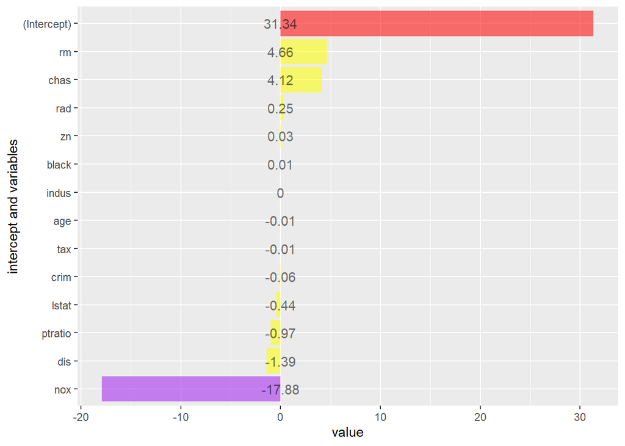

```r
ggplot(data = train_plot_data, aes(x= reorder(row.names(train_plot_data),train_fit$coefficients) ,y = train_fit$coefficients, alpha = 0.2)) +
  geom_col(aes(fill = cut(train_fit$coefficients, breaks = c(-Inf,-10,10,Inf)))) +
  scale_fill_manual(values = c("purple","yellow","red")) +
  labs(x = "intercept and variables", y = "value") +
  coord_flip() +
  theme(legend.position = "none") +
  geom_text(aes(label = round(train_fit$coefficients,2), y=0))
```